# Ploting Marginal Effects for a Regression Model with an Interaction Term

Miles D. Williams

University of Illinois at Urbana-Champaign

November 3, 2017

While several packages with functions that plot marginal effects already exist (such as `interplot`), these methods usually have limited applicability to only a certain set of regression objects. While plotting marginal effects can be done “by hand” in R rather easily, it would be best to avoid having to do this every time one runs into an issue using functions such as `interplot()` when one has to utilize models such as the `lmrob()` function in the `robustbase` package, which does not work with `interplot()`. To get around this issue, I detail below the `meplot()` function, which will take care of all the heavy lifting involved in creating a marginal effect plot, requiring the user to supply only the regression model object and the two variables that have been interacted in said model.

# Doing It the Hard Way

Marginal effects (ME) are typically computed for multiple regression models where an interaction term is included, such as follows:

$$y_i=\beta_0+\beta_1x_i+\beta_2z_i + \beta_3(x_i \times z_i) + \epsilon_i$$

Once this model is estimated, the instantaneous effect of $x_i$ on $y_i$ as $z_i$ varies (or vice versa) is calculated

$$\frac{\partial y}{\partial x} = \hat{\beta_x} + \hat{\beta}_{xz}z_i$$

along with standard errors

$$SE(\partial y/\partial x) = \sqrt{cov(x_i, x_i) + z_i^2cov(x_iz_i, x_iz_i) + 2z_icov(x_i, x_iz_i)}$$

where the upper and lower bounds are estimated as follows:

$$\frac{\partial y}{\partial x} \pm t^*SE(\partial y/\partial x)$$

Doing the math in R is fairly straightforward. First, I estimate a regression model with an interaction term. Below, I utilize data from `mtcars` (one of the toy datasets in R), and I estimate a model where miles per gallon for a set of cars (`mpg`) is a function of horsepower (`hp`) and weight (`wt`).

```r
mod <- lm(mpg ~ hp + wt + hp*wt, data=mtcars)
```

I then extract model estimates and the covariance matrix to compute marginal effects.

```r
beta.hat <- coef(mod)

cov <- vcov(mod)

z0 <- seq(min(mtcars$wt), max(mtcars$wt), length.out = 1000)
# calculate the instantaneous effect of x as z varies
dy.dx <- beta.hat["hp"] + beta.hat["hp:wt"]*z0
# calculate the standard error of each estimated effect
se.dy.dx <- sqrt(cov["hp", "hp"] + z0^2*cov["hp:wt", "hp:wt"] + 2*z0*cov["hp", "hp:wt"])
# calculate upper and lower bounds of a 95% CI
upr <- dy.dx + 1.96*se.dy.dx
lwr <- dy.dx - 1.96*se.dy.dx
```

I then use the above to plot marginal effects.

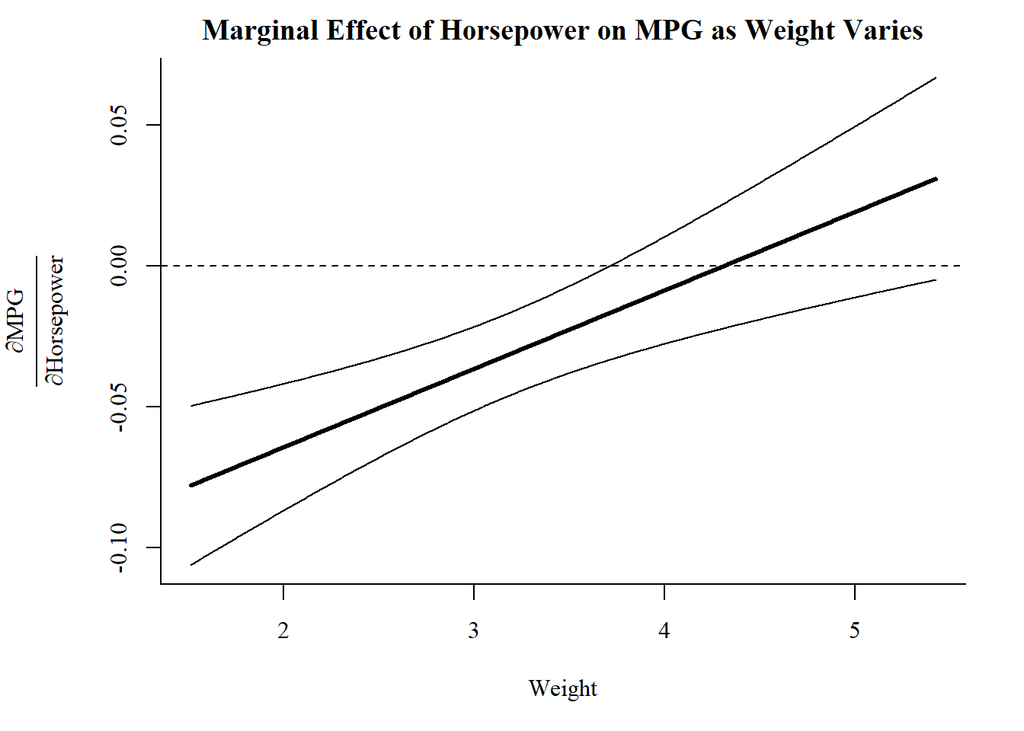

```r
par(family="serif",bty="l",mar=c(5,5.5,2,2))
plot(x=z0, y=dy.dx,type="n",xlim=c(min(z0),max(z0)),
     ylim=c(min(lwr),max(upr)),
     xlab = "Weight",
     ylab = expression(frac(partialdiff*paste("MPG"),
                            partialdiff*paste("Horsepower"))),
     main="Marginal Effect of Horsepower on MPG as Weight Varies")
lines(z0, dy.dx, lwd = 3)
lines(z0, lwr)
lines(z0, upr)
abline(h=0,lty=2)
```

# Doing It the Easy Way

While doing all the above works just fine, “just fine” requires a lot of lines of code, which can get quite tedious if I want to plot a lot of marginal effects. Thankfully, I can do better than just fine.

Enter `meplot()`. `meplot()` will do all the above math and plot the margial effects, all while requiring little effort on the part of the user. Let’s see it in action.

First, the function itself, with all its dirty inards:

```r
# ------------------------------------
# Create Marginal Effect Plot Function
# ------------------------------------
meplot <- function(model,var1,var2,ci=.95,xlab=var2,ylab=var1,main="Marginal Effect Plot"){
  alpha <- 1-ci
  z <- qnorm(1-alpha/2)
  beta.hat <- coef(model)
  cov <- vcov(model)
  z0 <- seq(min(model$model[,var2],na.rm=T),max(model$model[,var2],na.rm=T),length.out=1000)
  dy.dx <- beta.hat[var1] + beta.hat[paste(var1,var2,sep=":")]*z0
  se.dy.dx <- sqrt(cov[var1,var1] + z0^2*cov[paste(var1,var2,sep=":"),paste(var1,var2,sep=":")] + 2*z0*cov[var1,paste(var1,var2,sep=":")])
  upr <- dy.dx + z*se.dy.dx
  lwr <- dy.dx - z*se.dy.dx
  plot(x=z0, y=dy.dx,type="n",xlim=c(min(z0),max(z0)),
       ylim=c(min(lwr),max(upr)),
       xlab = xlab,
       ylab = paste("Marginal Effect of",var1),
       main = main)
  lines(z0, dy.dx, lwd = 3)
  lines(z0, lwr)
  lines(z0, upr)
  abline(h=0,lty=2)
}
```

Let’s see it in action. Below, I utilize the `mod` object I created above.

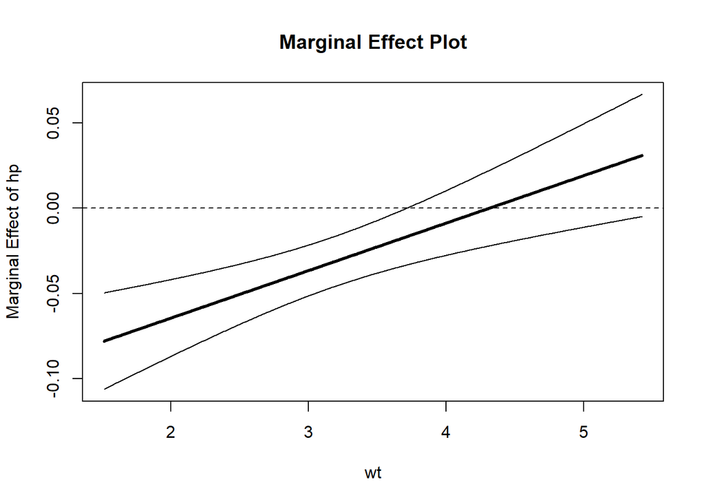

```r
meplot(model=mod,var1="hp",var2="wt")
```

Also, `meplot()` will work with any base R plotting parameters specifiable with the `par()` function, which is good to know if the default parameters aren’t quite your style.

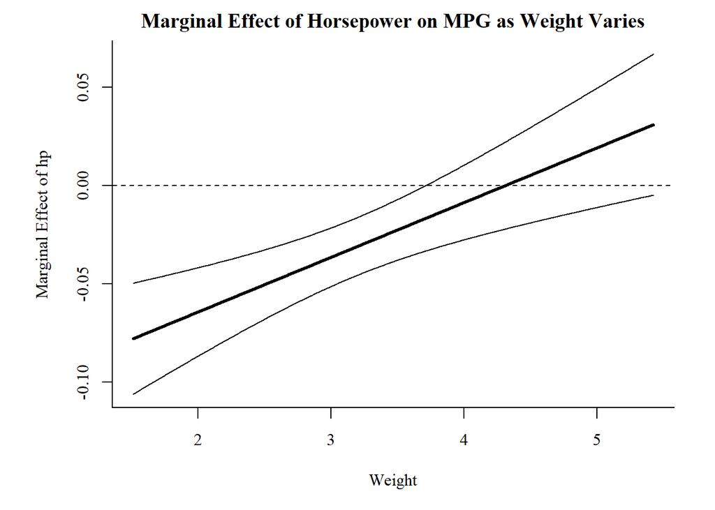

```r
par(family="serif",bty="l",mar=c(5,5.5,2,2))
meplot(model=mod,var1="hp",var2="wt",xlab = "Weight",
     ylab = expression(frac(partialdiff*paste("MPG"),
                            partialdiff*paste("Horsepower"))),
     main="Marginal Effect of Horsepower on MPG as Weight Varies")
```